# Project 2: Tuesday Data

## Introduction:

In this project I will be using the `OnlineNewsPopularity.csv` data, which is a data set about various articles that are published along with various article and publishing attributes. The goal of this project is to accurately predict the number of times that a particular article will be "shared" on social media given its attributes.

## Data Summary

There are 5 groups of variables that have similar themes in this data set. The variables within each group likely have high correlations with each other. The variable groups are about:

1. Number of words/keywords/media
2. Digital channel type
3. Shares by keyword
4. Typical shares of articles in Mashable
5. Sentiment and Polarity

**Correlation Plots for Number of Word Variables:**

As seen below, many of the variables are highly correlated and might need to be removed.

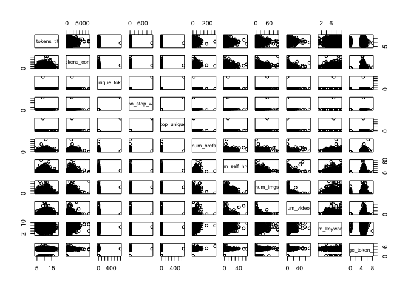

**Data Channel Type:**

**Shares by Keyword Variables:**

As seen below, many of the variables seem correlated and might need to be removed.

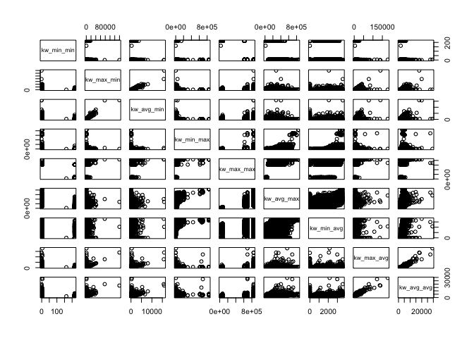

**Mashable Shares Variables:**

These variables seem to have very similar distributions. It is not clear whether there will be any relationship with overall shares.

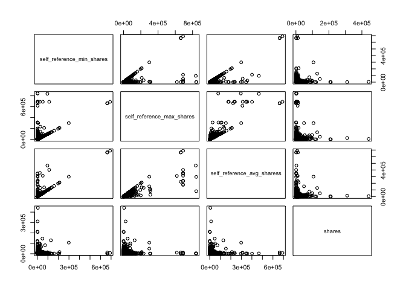

**Sentiment/Polarity Variables:**

When comparing variables measuring positive and negative polarities, there seems to be moderate to strong correlations.

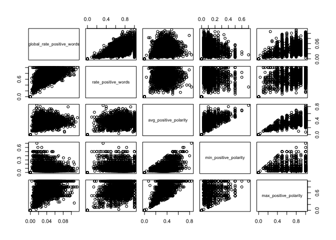

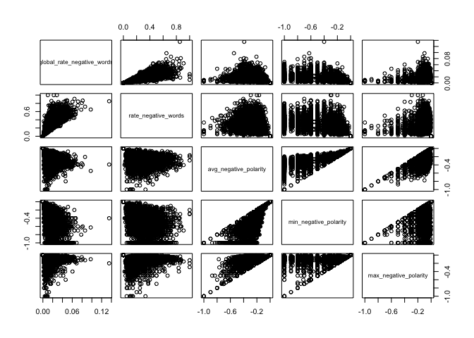